# Part I - Prosper Loan Data Exploration

## by Wellington Chentulo

- Introduction
- Preliminary Wrangling
- Univariate Exploratoration
- Bivariate Exploratoration
- Multivariate Exploratoration
- Conclusions

## Introduction

This project explores loan data from Prosper, which contains 113,937 loans with 81 variables on each loan. Some of the loan features are listed and briefly defined below. The other loan variables will be introduced during the data exploration:

- **LoanNumber**: Unique numeric value associated with the loan.
- **CreditGrade**: The Credit rating that was assigned at the time the listing went live.
- **Term**: The length of the loan expressed in months.
- **LoanStatus**: The current status of the loan: Cancelled, Chargedoff, Completed, Current, Defaulted, FinalPaymentInProgress, PastDue.
- **BorrowerRate**: The Borrower's interest rate for this loan.
- **LoanOriginalAmount**: The origination amount of the loan.

## Preliminary Wrangling

```python
# Import all necessary packages for the data exploration and set plots to be embedded inline
import numpy as np
import pandas as pd
import matplotlib.pyplot as plt
import seaborn as sb

%matplotlib inline
```

### Load Data

The code below loads the dataset into a Pandas dataframe and displays `shape` of the dataset and the first 10 loans.

```python
# Read the dataset and load it into a dataframe

loans = pd.read_csv('prosper_loan_data.csv')

# View the structure of the dataset
print(loans.shape)
loans.head(10)
```

```
(113937, 81)
```

|  | ListingKey | ListingNumber | ListingCreationDate | CreditGrade | Term | LoanStatus | ClosedDate | BorrowerAPR | BorrowerRate | LenderYield | ... | LP_ServiceFees | LP_CollectionFees | LP_GrossPrincipalLoss | LP_NetPrincipalLoss | LP_NonPrincipalRecoverypayments | PercentFunded | Recommendations | InvestmentFromFriendsCount | InvestmentFromFriendsAmount | Investors |
| --- | --- | --- | --- | --- | --- | --- | --- | --- | --- | --- | --- | --- | --- | --- | --- | --- | --- | --- | --- | --- | --- |
| 0 | 1021339766868145413AB3B | 193129 | 2007-08-26 19:09:29.263000000 | C | 36 | Completed | 2009-08-14 00:00:00 | 0.16516 | 0.1580 | 0.1380 | ... | -133.18 | 0.0 | 0.0 | 0.0 | 0.0 | 1.0 | 0 | 0 | 0.0 | 258 |
| 1 | 10273602499503308B223C1 | 1209647 | 2014-02-27 08:28:07.900000000 | NaN | 36 | Current | NaN | 0.12016 | 0.0920 | 0.0820 | ... | 0.00 | 0.0 | 0.0 | 0.0 | 0.0 | 1.0 | 0 | 0 | 0.0 | 1 |
| 2 | 0EE9337825851032864889A | 81716 | 2007-01-05 15:00:47.090000000 | HR | 36 | Completed | 2009-12-17 00:00:00 | 0.28269 | 0.2750 | 0.2400 | ... | -24.20 | 0.0 | 0.0 | 0.0 | 0.0 | 1.0 | 0 | 0 | 0.0 | 41 |
| 3 | 0EF5356002482715299901A | 658116 | 2012-10-22 11:02:35.010000000 | NaN | 36 | Current | NaN | 0.12528 | 0.0974 | 0.0874 | ... | -108.01 | 0.0 | 0.0 | 0.0 | 0.0 | 1.0 | 0 | 0 | 0.0 | 158 |
| 4 | 0F023589499656230C5E3E2 | 909464 | 2013-09-14 18:38:39.097000000 | NaN | 36 | Current | NaN | 0.24614 | 0.2085 | 0.1985 | ... | -60.27 | 0.0 | 0.0 | 0.0 | 0.0 | 1.0 | 0 | 0 | 0.0 | 20 |
| 5 | 0F05359734824199381F61D | 1074836 | 2013-12-14 08:26:37.093000000 | NaN | 60 | Current | NaN | 0.15425 | 0.1314 | 0.1214 | ... | -25.33 | 0.0 | 0.0 | 0.0 | 0.0 | 1.0 | 0 | 0 | 0.0 | 1 |
| 6 | 0F0A3576754255009D63151 | 750899 | 2013-04-12 09:52:56.147000000 | NaN | 36 | Current | NaN | 0.31032 | 0.2712 | 0.2612 | ... | -22.95 | 0.0 | 0.0 | 0.0 | 0.0 | 1.0 | 0 | 0 | 0.0 | 1 |
| 7 | 0F1035772717087366F9EA7 | 768193 | 2013-05-05 06:49:27.493000000 | NaN | 36 | Current | NaN | 0.23939 | 0.2019 | 0.1919 | ... | -69.21 | 0.0 | 0.0 | 0.0 | 0.0 | 1.0 | 0 | 0 | 0.0 | 1 |
| 8 | 0F043596202561788EA13D5 | 1023355 | 2013-12-02 10:43:39.117000000 | NaN | 36 | Current | NaN | 0.07620 | 0.0629 | 0.0529 | ... | -16.77 | 0.0 | 0.0 | 0.0 | 0.0 | 1.0 | 0 | 0 | 0.0 | 1 |
| 9 | 0F043596202561788EA13D5 | 1023355 | 2013-12-02 10:43:39.117000000 | NaN | 36 | Current | NaN | 0.07620 | 0.0629 | 0.0529 | ... | -16.77 | 0.0 | 0.0 | 0.0 | 0.0 | 1.0 | 0 | 0 | 0.0 | 1 |

10 rows × 81 columns

### Dataset Properties

Pandas's `info()` function gives a detailed view of the properties of the dataset and its features. As can be seen from the results of the code below, there are 113,937 loan observations with 81 features. Unfortunately, there are some features that do not contain all the values and hence have missing values.

```python
# Display the dataset's variable data types and non-null observations
loans.info()
```

```
<class 'pandas.core.frame.DataFrame'>
RangeIndex: 113937 entries, 0 to 113936
Data columns (total 81 columns):
ListingKey                             113937 non-null object
ListingNumber                          113937 non-null int64
ListingCreationDate                    113937 non-null object
CreditGrade                            28953 non-null object
Term                                   113937 non-null int64
LoanStatus                             113937 non-null object
ClosedDate                             55089 non-null object
BorrowerAPR                            113912 non-null float64
BorrowerRate                           113937 non-null float64
LenderYield                            113937 non-null float64
EstimatedEffectiveYield                84853 non-null float64
EstimatedLoss                          84853 non-null float64
EstimatedReturn                        84853 non-null float64
ProsperRating (numeric)                84853 non-null float64
ProsperRating (Alpha)                  84853 non-null object
ProsperScore                           84853 non-null float64
ListingCategory (numeric)              113937 non-null int64
BorrowerState                          108422 non-null object
Occupation                             110349 non-null object
EmploymentStatus                       111682 non-null object
EmploymentStatusDuration               106312 non-null float64
IsBorrowerHomeowner                    113937 non-null bool
CurrentlyInGroup                       113937 non-null bool
GroupKey                               13341 non-null object
DateCreditPulled                       113937 non-null object
CreditScoreRangeLower                  113346 non-null float64
CreditScoreRangeUpper                  113346 non-null float64
FirstRecordedCreditLine                113240 non-null object
CurrentCreditLines                     106333 non-null float64
OpenCreditLines                        106333 non-null float64
TotalCreditLinespast7years             113240 non-null float64
OpenRevolvingAccounts                  113937 non-null int64
OpenRevolvingMonthlyPayment            113937 non-null float64
InquiriesLast6Months                   113240 non-null float64
TotalInquiries                         112778 non-null float64
CurrentDelinquencies                   113240 non-null float64
AmountDelinquent                       106315 non-null float64
```

[output cut: 31 more lines]

```
LP_CustomerPayments                    113937 non-null float64
LP_CustomerPrincipalPayments           113937 non-null float64
LP_InterestandFees                     113937 non-null float64
LP_ServiceFees                         113937 non-null float64
LP_CollectionFees                      113937 non-null float64
LP_GrossPrincipalLoss                  113937 non-null float64
LP_NetPrincipalLoss                    113937 non-null float64
LP_NonPrincipalRecoverypayments        113937 non-null float64
PercentFunded                          113937 non-null float64
Recommendations                        113937 non-null int64
InvestmentFromFriendsCount             113937 non-null int64
InvestmentFromFriendsAmount            113937 non-null float64
Investors                              113937 non-null int64
dtypes: bool(3), float64(50), int64(11), object(17)
memory usage: 68.1+ MB
```

### What is the structure of your dataset?

The Prosper loan dataset contains 113937 loans, with 81 features recorded for each loan. Most loan features contain numeric values. For example, the variables `Term`, `BorrowerRate` and `LoanOriginalAmount` are numeric variables while `CreditGrade` and `LoanStatus` are string varibles containing categorical variables. Other variables such `IsBorrowerHomeowner` and `IncomeVerifiable` contain boolean values.

### What is/are the main feature(s) of interest in your dataset?

In this project, I am interested in finding out what features influence the borrower's interest rate for the loan and whether these features are best for predicting the borrower's interest rate for the loan.

### What features in the dataset do you think will help support your investigation into your feature(s) of interest?

My expectation is that the borrower's interest rate will be influenced by features such as the loan term, the loan amount and the Prosper score. I also expect the number of current delinquencies to have an influence on the borrower's interest rate.

## Univariate Exploration

In this section, i investigate the distributions of the individual variables that I will be exploring in this project. Before beginning any explorations, I first create a copy of the original dataset and then keep only the features in the data set that I am going to work with.

```python
# Create a copy of the dataset and keep only features of interest
loan_data = loans.copy()

# Create a list of the columns that will be used in this project exploration
columns_of_interest = ['Term',
                       'BorrowerRate',
                       'ProsperScore',
                       'IsBorrowerHomeowner',
                       'Investors',
                       'IncomeVerifiable',
                       'AmountDelinquent',
                       'LoanOriginalAmount',
                       'Recommendations',
                       'LenderYield',
                       'CurrentDelinquencies'
                      ]

loan_data = loan_data[columns_of_interest]
loan_data.info()
```

```
<class 'pandas.core.frame.DataFrame'>
RangeIndex: 113937 entries, 0 to 113936
Data columns (total 11 columns):
Term                    113937 non-null int64
BorrowerRate            113937 non-null float64
ProsperScore            84853 non-null float64
IsBorrowerHomeowner     113937 non-null bool
Investors               113937 non-null int64
IncomeVerifiable        113937 non-null bool
AmountDelinquent        106315 non-null float64
LoanOriginalAmount      113937 non-null int64
Recommendations         113937 non-null int64
LenderYield             113937 non-null float64
CurrentDelinquencies    113240 non-null float64
dtypes: bool(2), float64(5), int64(4)
memory usage: 8.0 MB
```

### Drop *null* values

```python
# Drop all observations with null values
loan_data.dropna(inplace=True)

# Convert ProsperScore and CurrentDelinquencies to be integer values
loan_data[["ProsperScore", "CurrentDelinquencies"]] = loan_data[["ProsperScore", "CurrentDelinquencies"]].astype('int64')

# Drop all ProsperScore values greater than 10
loan_data.drop(loan_data[loan_data["ProsperScore"] > 10].index, inplace=True)

loan_data.info()
```

```
<class 'pandas.core.frame.DataFrame'>
Int64Index: 83397 entries, 1 to 113936
Data columns (total 11 columns):
Term                    83397 non-null int64
BorrowerRate            83397 non-null float64
ProsperScore            83397 non-null int64
IsBorrowerHomeowner     83397 non-null bool
Investors               83397 non-null int64
IncomeVerifiable        83397 non-null bool
AmountDelinquent        83397 non-null float64
LoanOriginalAmount      83397 non-null int64
Recommendations         83397 non-null int64
LenderYield             83397 non-null float64
CurrentDelinquencies    83397 non-null int64
dtypes: bool(2), float64(3), int64(6)
memory usage: 6.5 MB
```

### What is the distribution of borrower rates?

I start by looking at the main variable of interest: `BorrowerRate`. I try to look at what the distribution of borrower's interest rates is like in this data set. The histogram plotted below shows the distribution of borrower interest rates.

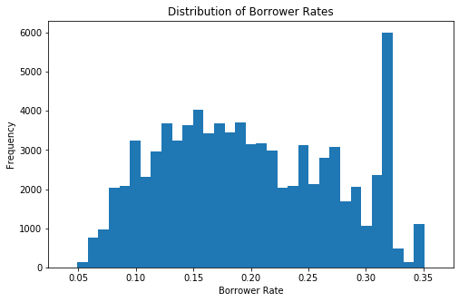

```python
# Plot the histogram of the borrower rates as a proportions
loan_data.BorrowerRate.plot.hist(bins=35, figsize=(8, 5));
plt.xlabel('Borrower Rate');
plt.title('Distribution of Borrower Rates');
```

From the histgram above, my observation is that most of the interest rates were concentrated between 9 and 25 percent. However, the data shows one peak in the borrower rate between 31 and 32 percent. Below I generate summary statistics for borrower rate and then plot a boxplot in order to check for the presence of outliers in the borrower rates variable.

```python
# print summary statistics of the borrower rates as proportions
print(loan_data['BorrowerRate'].describe())
```

```
count    83397.000000
mean         0.197815
std          0.073931
min          0.040000
25%          0.139600
50%          0.189900
75%          0.257900
max          0.360000
Name: BorrowerRate, dtype: float64
```

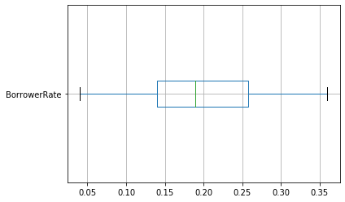

```python
# Plot a boxplot to check for outliers in the borrower rates
loan_data.boxplot(column=['BorrowerRate'], vert=False);
```

The plotted boxplot above shows no indication of any outliers in the borrower rate variable.

### What is the distribution of the loan term?

The loan term is the length of the loan expressed in months. I want to find out how the loan terms are distributed, i.e., are there more loans in the long-term or short-term? I try to answer this by plotting a bar chart below and visualise how the loan term is distributed.

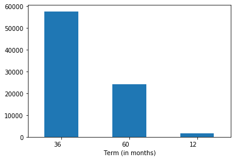

```python
# Plot a bar chart to show the the distribution of the loan terms
loan_data.Term.value_counts().plot(kind='bar')
plt.xlabel('Term (in months)')
plt.xticks(rotation=0, ha='right');
```

The bar chart above shows that most of the loans are distributed over a term of 36 months, followed by 60 months and only a small fraction of the loans had a term of 12 months. This implies that more borrowers preferred to borrow for up to 3 years.

### How are the Prosper scores distributed?

The Prosper score is a discrete, ordinal variable that contains risk scores from 1 to 10, with 1 being the riskiest score and 10 the lowest-risk score. The bar chart below shows how the Prosper score is distributed

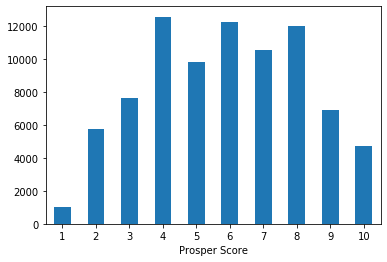

```python
# Plot a bar chart of the ProsperScore variable
loan_data['ProsperScore'].value_counts(sort=False).plot.bar(rot=0)
plt.xlabel('Prosper Score');
```

In my observation from the bar chart above, most of the loans had a Prosper score between 2 and 9, with 4, 6 and 8 being the three most common scores.

### How many borrowers own homes?

The bar chart belows shows the distribution of home ownership among borrowers.

```python
loan_data['IsBorrowerHomeowner'].value_counts()
```

```
True     43283
False    38801
Name: IsBorrowerHomeowner, dtype: int64
```

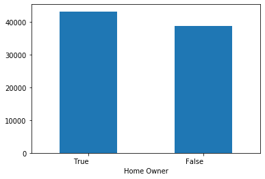

```python
# Plot bar chart to show the number of borrowers with/without home ownership
loan_data['IsBorrowerHomeowner'].value_counts().plot.bar();
plt.xticks(rotation=360, ha='right');
plt.xlabel('Home Owner');
```

The graph shows that there are more home owners among the borrowers, although there is not much of a difference.

### What is the distribution of borrowers with verifiable income?

I want to find out how many borrowers indicated that they have the required documentation to support their income. This information is shown in the bar chart plotted below.

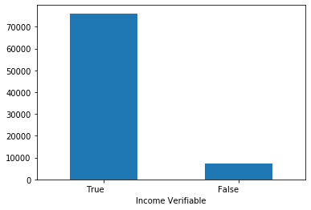

```python
#### Distribution of Borrowers with verifiable income
loan_data['IncomeVerifiable'].value_counts().plot(kind='bar');
plt.xticks(rotation=360, ha='right');
plt.xlabel('Income Verifiable');
```

From the above graph, it is clear that more borrowers provided income information that could verify.

### How are loan amounts distributed?

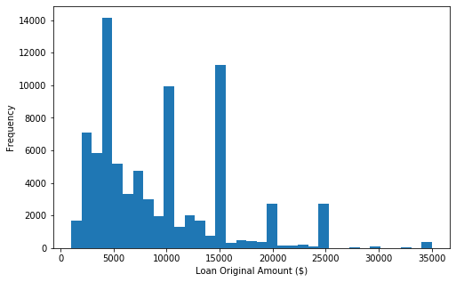

```python
# Plot histogram of original loan amounts
loan_data['LoanOriginalAmount'].plot.hist(figsize=(8, 5), bins=35);
plt.xlabel('Loan Original Amount ($)');
```

The loan amounts appear to be positively skewed, with some observable spikes in loan amounts at 5000, 10000 and 15000. Summary statistics are generated below and a boxplot will be plotted to check for the presence of outliers in the loan amount variable.

```python
# generate summary statistics of loan amount
loan_data['LoanOriginalAmount'].describe()
```

```
count    83397.000000
mean      8982.621185
std       6202.474999
min       1000.000000
25%       4000.000000
50%       7500.000000
75%      13000.000000
max      35000.000000
Name: LoanOriginalAmount, dtype: float64
```

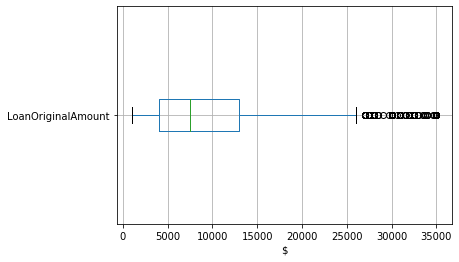

```python
# Plot a boxplot to check for the presence of outliers in the loan original amounts
loan_data.boxplot(column=['LoanOriginalAmount'], vert=False);
plt.xlabel('$');
```

The boxplot shows the presence of outliers in the loan amounts. These will have to be dropped from the dataset.

```python
# Remove outliers from loan amount using the interquartile range method
# q1 = lower quartile
# q3 = upper quartile
# iqr = interquartile range

# Compute the lower and uppper quartiles
q1, q3 = np.percentile(loan_data['LoanOriginalAmount'] , [25,75])
iqr = q3 - q1

# Compute the lower and upper bounds
lower_bound = q1 - 1.5*iqr
upper_bound = q3 + 1.5*iqr

print(f'lower bound: {lower_bound}\nupper bound: {upper_bound}')
```

```
lower bound: -9500.0
upper bound: 26500.0
```

The boxplot shows outlier loan amounts are present in the data. These outlying observations will be dropped using the interquartile range method, and all amounts greater that 26500 were deemed outliers and were dropped from the dataset. There are no negative loan amounts; therefore, only loan amounts greater than $26,500 will be dropped from the dataset.

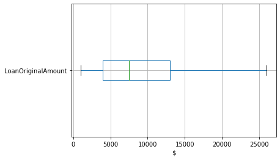

```python
# Drop all loan observations with amounts greater than $26,500
loan_data.drop(loan_data[loan_data["LoanOriginalAmount"] > 26500].index, inplace=True)

# Confirm that there are no outliers
loan_data.boxplot(column=['LoanOriginalAmount'], vert=False);
plt.xlabel('$');
```

```python
# generate summary statistics of loan amount
loan_data['LoanOriginalAmount'].describe()
```

```
count    82844.000000
mean      8819.831708
std       5889.738460
min       1000.000000
25%       4000.000000
50%       7500.000000
75%      13000.000000
max      26000.000000
Name: LoanOriginalAmount, dtype: float64
```

The boxplot and summary statistics above show that no outliers are present in the data.

### How are the borrowers' current delinquencies distributed?

The current delinquencies variable contains (for each borrower) the number of accounts delinquent at the time the credit profile was pulled. The plotted chart below shows a positive skewness in the current delinquencies of the borrowers, with more borrowers having no delinquencies at the time.

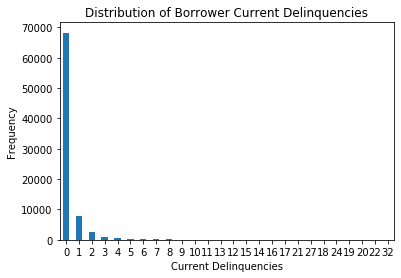

```python
# Plot the distribution of borrower delinquencies
loan_data['CurrentDelinquencies'].value_counts().plot.bar(rot=0);
plt.title('Distribution of Borrower Current Delinquencies');
plt.ylabel('Frequency')
plt.xlabel('Current Delinquencies');
```

### What are lender yields distributed?

The histogram below shows how the lenders yield on each loan is distributed in the data.

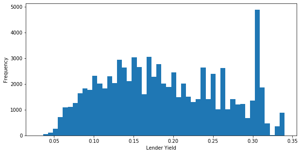

```python
# Plot the distribution of lender yields as percents
loan_data['LenderYield'].plot.hist(figsize=[10, 5], bins=50);
plt.xlabel('Lender Yield');
```

The pattern of this histogram looks similar to that of the borrower rates on the loan. The summary statistics and boxplot below are generated to detect outliers.

```python
# generate summary statistics as percents
loan_data['LenderYield'].describe()
```

```
count    82844.000000
mean         0.188242
std          0.073974
min          0.030000
25%          0.129900
50%          0.179900
75%          0.249900
max          0.340000
Name: LenderYield, dtype: float64
```

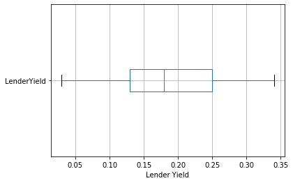

```python
# Check for outliers in the lender yield as propotions
loan_data.boxplot(column=['LenderYield'], vert=False);
plt.xlabel('Lender Yield');
```

The boxplot does not show any outliers present in the lender yield variable.

### Discuss the distribution(s) of your variable(s) of interest. Were there any unusual points? Did you need to perform any transformations?

*Before creating any visualisations to explore the distributions of the variables, all null values were dropped from the dataset.*

**`BorrowerRate`**: In my observation of the borrower rate, most of the rates were concentrated between 9 and 25 percent. However, the data showed one peak in the borrower rate between 31 and 32 percent. A boxplot was plotted and there were no outliers detected in the borrower rates variable.

### Of the features you investigated, were there any unusual distributions? Did you perform any operations on the data to tidy, adjust, or change the form of the data? If so, why did you do this?

**`Term`**: I looked at the distribution of loan terms, which showed that most of the loans had a term of 36 months, followed by 60 months and only a small fraction of the loans had a term of 12 months.

**`ProsperScore`**: I observed that soome Prosper scores were greater than 10. These were dropped from the dataset. In my observation, most of the loans had a Prosper score between 2 and 9, with 4, 6 and 8 being the three most common scores.

**`LoanOriginalAmount`**: The loan amounts appeared to show a *positively skewed distribution*, with some observable spikes in loan amounts at 5000, 10000 and 15000. A boxplot was plotted, and it showed that outliers were present in the loan amount variable. The outlier loan amounts were detected using the interquartile range method, and all amounts greater that 26500 were deemed outliers and were dropped from the dataset.

**`CurrentDelinquencies`**: The `CurrentDelinquencies` variable, which is the number of borrower accounts delinquent at the time the credit profile was pulled, also showed a positively skewed distribution, with the highest number of borrowers having no delinquent accounts at the time.

**`LenderYield`**: The lender's yield on the loan showed a distribution similar to that of the borrower rate. This can be expected to be the case since the variable definition of the `LenderYield` variable is "*`the interest rate on the loan less the servicing fee`*".

## Bivariate Exploration

In this section, I investigate relationships between pairs of variables in the loans dataset. I will first look at the pairwise correlations present between the features in the dataset.

```python
# Separate numeric and categorical variables
numeric_vars = ['Term', 'BorrowerRate', 'LoanOriginalAmount', 'Investors', 'ProsperScore',
                'LenderYield', 'CurrentDelinquencies', 'Recommendations', 'AmountDelinquent']

categoric_vars = ['IsBorrowerHomeowner', 'IncomeVerifiable']
```

## How do the numeric variables relate with each other?

I use the correlation heatmap below will to try and answer how the numeric variables are related to the variable of interest and to each other. The heatmap also shows the correlation coefficient between each variable pair.

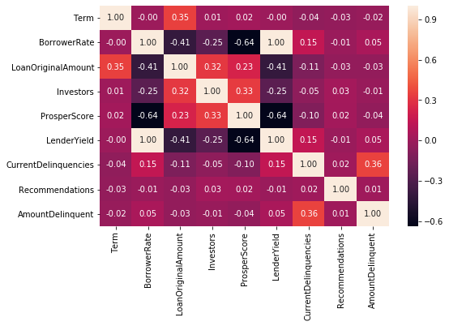

```python
# Plot a correlation heatmap to chek for variables that are correlated
plt.figure(figsize = [8, 5]);
sb.heatmap(loan_data[numeric_vars].corr(), annot=True, fmt='.2f');
```

### Scatterplot of borrower rate vs lender yield

The scatterplot below shows the perfect positive correlation between the borrower's inteterest and the lender's yield.

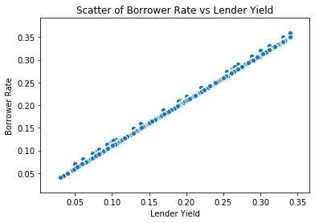

```python
# Plot a scatterplot between lender yield and borrower rate
sb.scatterplot(x="LenderYield", y="BorrowerRate", data=loan_data);
plt.xlabel('Lender Yield');
plt.ylabel('Borrower Rate');
plt.title('Scatter of Borrower Rate vs Lender Yield');
```

## How is the lender yield distributed for each Prosper score category?

In this section, I wish to find out how the lender's yield on a loan is distributed for each Prosper risk score. How does the lender yield vary in each risk category? The Prosper score ranges from 1-10, with 10 being the best, or lowest risk score. In order to answer this question, I will plot boxplots for each Prosper score, which will show the distribution of lender yields for in each category.

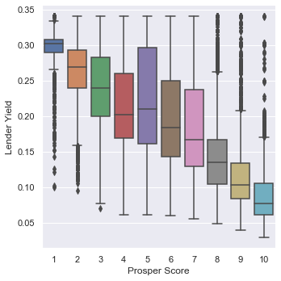

```python
# Plot a boxplot and see how the lender yield is distributed for each category.

sb.catplot(data=loan_data, x="ProsperScore", y="LenderYield", kind="box", dodge=False)
plt.xlabel('Prosper Score');
plt.ylabel ('Lender Yield');
```

In the boxplot above, I observed that as the risk level of the loan increased (Prosper score closer to 1) so did the lenders' yield on the loan. And as loan's risk reduced (Prosper scores closer to 10) the lenders' yield reduced. This implies that riskier loans yield higher returns for the lender.

### Talk about some of the relationships you observed in this part of the investigation. How did the feature(s) of interest vary with other features in the dataset?

- **`BorrowerRate and LenderYield`**: The borrower's interest rate on the loan showed a positive correlation with the lender's yield on the loan. This result supports the expected result since the lender's yield is equal to the borrower's interest rate less servicing fees.
- **`BorrowerRate and ProsperScore`**: The borrower interest rate on the loan and the Prosper score showed a negative correlation of `-0.64`; this is expected since a higher Prosper score indicates a low-risk borrower and lower risk would attract a lower loan interest rate for the borrower.

### Did you observe any interesting relationships between the other features (not the main feature(s) of interest)?

- The same relationship exhibited between the borrower rate and the Prosper score is also exhibited between the lender yield and the Prosper score.
- The number of investors showed a small positive correlation with both the loan amount and the Prosper score
- I observed that there is a small negative correlation between the lender's yield and the loan amount. The other variables' correlations were negligible values, indicating very small interactions between them.

## Multivariate Exploration

In this section I will create plots of at least three variables to investigate any interctions between them. Particularly, I look at how the categorical variables interact with the variable of interest.

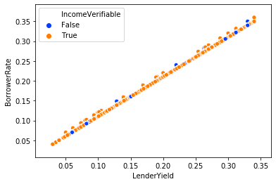

```python
# Plot a scatter plot to show how income verifiability relates with borrower's interest rate and lenders' yields
sb.scatterplot(
    x='LenderYield',
    y='BorrowerRate',
    data=loan_data,
    palette='bright',
    hue='IncomeVerifiable');
```

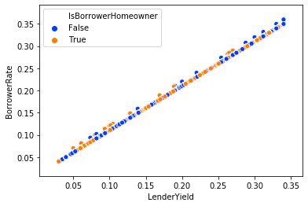

```python
# Plot a scatter plot to show how loan amount relates with borrower's interest rate and lenders' yields
sb.scatterplot(
    x='LenderYield',
    y='BorrowerRate',
    data=loan_data,
    palette='bright',
    hue='IsBorrowerHomeowner');
```

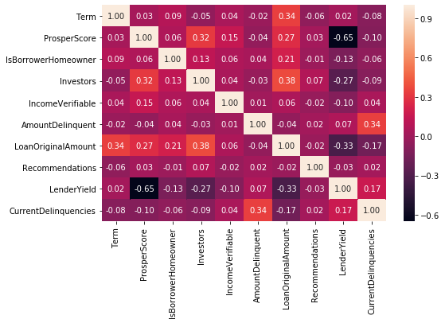

```python
other_vars = ['Term',
              'ProsperScore',
              'IsBorrowerHomeowner',
              'Investors',
              'IncomeVerifiable',
              'AmountDelinquent',
              'LoanOriginalAmount',
              'Recommendations',
              'LenderYield',
              'CurrentDelinquencies']

plt.figure(figsize = [8, 5]);
sb.heatmap(loan_data[other_vars].corr(), annot=True, fmt='.2f');
```

### Talk about some of the relationships you observed in this part of the investigation. Were there features that strengthened each other in terms of looking at your feature(s) of interest?

I plotted a scatter plot to check how the borrower's income verifiability and home owndership relate with the relationship between loans interest rate and the lender yield. I observed that the majority of the observations that formed the positive correlation between borrower rate and lender yield were those loans whose borrower's income was verifiable. And the same was observed for home ownership of the borrower. However, the correlation between the borrwer rate and borrower's home ownership status or income verifiability was very negligible and hence it could not be concluded that these variables influence the borrower's rate for a loan.

### Were there any interesting or surprising interactions between features?

One interesting interaction was that the current delinquencies and the deliquencies are positively correlated, despite the level of correlation being small. However, there seems not to be any interactions between the categoricals variables and the other variables.

## Conclusions

The main aim of this exploration was to find out what features affect the borrower's interest rate. Before beginning my exploration, I first created a copy of the dataset, dropped all columns not relevant to the exploration. Then I cleaned the data by dropping `null` values and incorrect data. During univariate exploration, I plotted graphs for each individual variable in order to check for the distribution of each variable.

In bivariate eploraionn I observed a positive relatioship between the borrower rate and the lender's yield, and a negative relationship between borrower rate and the Prosper score.

In multivariate exploration, I plotted two scatter plots between the borrower rate, lender yield and the categorical variables `incomeVerifiable` and `IsBorrowerHomeOwner`. Despite seeming to fall on the trend line between borrower rate and lender yield, these categorical variables do not appear to influence the borrower rate.

Table of Contents